# OLDW - Prophet Model for Coursera, Parameters Tuning

Ming-Chen (Amy) Lu, mingchlu@umich.edu

August 12, 2020

# Data Prep

I kept the earliest enrollment for each user and also removed courses with total enrollments fewer than 30.

```r
# Libraries
library(dplyr)
library(tidyr)
library(ggplot2)
library(ggpubr)
library(stringr)
library(data.table)
library(prophet)
library(DT)
setwd("/Users/Amy/Desktop/AI/OLDW")
dt_coursera = fread("dt_coursera.csv")

# Check total of data points for each course
dt_crsa_par = dt_coursera[, .(horizon = .N %/% 8,
                              algorithm = ifelse(.N < 100, 'Newton', 'LBFGS')),
                          by=CRSE_NM]
load("mod_ls.RData")
load("CV_ls.RData")

# A table showing all results: -------------------------------------------------
eval_mod = function(x) {
  rmse = round(sqrt(mean((x$y - x$yhat)^2)), 2)
  mape = round(mean(abs(x$y - x$yhat) / x$y) * 100, 2)
  return(list(rmse, mape))
}

tbl = as.data.frame(matrix(unlist(lapply(CV_ls, eval_mod)),
                           ncol = 2, byrow = TRUE))
tbl["course"] = names(CV_ls)
colnames(tbl)[1:2] = c("rmse", "mape")
tbl = tbl %>% select(course, mape, rmse) %>% arrange(mape)
```

# First Attempt - Baseline Model

Out of the 115 courses on Coursera, 89 courses was fitted. A table and plots for each course were generated to show the initial results.

The model fitting process involves  
1. Specifying `algorithm = 'Newton'` if sample size < 100; otherwise, `algorithm = 'LBFGS'`  
2. Predicting for the next 30 days  
3. Applying 10-fold cross validation to each course

Others were set as default values.

```r
datatable(tbl, caption = "Table 1: Baseline Model.")
```

|  | course | mape | rmse |
| --- | --- | --- | --- |
| 1 | Inferential Statistical Analysis with Python | 0.83 | 136.62 |
| 2 | Fitting Statistical Models to Data with Python | 0.91 | 95.19 |
| 3 | Managing Talent | 0.94 | 841.67 |
| 4 | Thoracic Oncology | 1.04 | 56.66 |
| 5 | Making Successful Decisions through the Strategy, Law &amp; Ethics Model | 1.08 | 101.67 |
| 6 | Sampling People, Networks and Records | 1.25 | 107.38 |
| 7 | Applied Machine Learning in Python | 1.28 | 4468.35 |
| 8 | Applied Text Mining in Python | 1.28 | 1853.88 |
| 9 | Data Collection: Online, Telephone and Face-to-face | 1.34 | 159.29 |
| 10 | Valuing Companies | 1.35 | 176.86 |

[output cut: 79 more lines]

# Second Attempt - Models that has MAPE > 10%

## Random Search

The author of the package suggests that `changepoint_prior_scale` and `seasonality_prior_scale` are two parameters that are valuable to tune, so I’ll start with these two. (https://github.com/facebook/prophet/issues/1058#issuecomment-510671302)

Here we used random search to find the best set of parameters within the range. The random search tends to perform better than grid search for hyper-parameter optimization. (Figure 1 of this paper http://www.jmlr.org/papers/volume13/bergstra12a/bergstra12a.pdf; https://github.com/facebook/prophet/issues/886#issuecomment-474055687)

Below shows the for loop for random search.

```r
# Set values for random search
set.seed(2020)
len = 10
cp_prior_vals = runif(len, 0, 30)
seas_prior_vals = runif(len, 10, 30)
tune_ls = list()
crse_name = tbl[tbl$mape > 10,]$course

for(j in crse_name) {
  # create empty vectors
  rmse = vector(length = len)
  mape = vector(length = len)

  # Random search `len` times for each course
  for (i in 1:len) {
    tryCatch({
      algorithm = dt_crsa_par[CRSE_NM == j]$algorithm
      mod = prophet(dt_coursera[CRSE_NM == j, .(ds, y)],
                    algorithm = algorithm,
                    changepoint.prior.scale = cp_prior_vals[i],
                    seasonality.prior.scale = seas_prior_vals[i])
      future = make_future_dataframe(mod, periods = 30, freq = "day")
      forecast = predict(mod, future)
      horizon = dt_crsa_par[CRSE_NM == j]$horizon
      cv = cross_validation(mod, horizon = horizon, units = "days")

      # Record RMSE and MAPE
      rmse[i] = performance_metrics(cv, metrics = 'rmse', rolling_window = 1)$rmse
      mape[i] = performance_metrics(cv, metrics = 'mape', rolling_window = 1)$mape*100
    }, error = function(e){
      cat("ERROR:", j, i, conditionMessage(e), "\n")})
  }

  # Combine the search into df and save it to list
  tryCatch({
    df = data.frame(cbind(rep(j, len), cp_prior_vals, seas_prior_vals,
                          round(rmse, 2), round(mape, 2)))
    colnames(df) = c("course", "cp_prior_vals", "seas_prior_vals",
                     "rmse", "mape")
    tune_ls[[j]] = df
  }, error = function(e){ cat("ERROR:", j, ".", conditionMessage(e), "\n")})

}
```

## Results

All courses except “Financial Accounting for Construction Projects” have improved.

```r
load("tune_ls.RData")
# Unlist results and pick the best one for each course: -------------------------
dt_tune = rbindlist(tune_ls) %>%
  .[order(mape), .SD, by=course] %>%
  .[(mape > 0) | (rmse > 0)] %>%
  .[, .SD[1], by=course] %>%
  merge(., tbl, by="course", suffixes=c("_new", "_old")) %>%
  .[, .(course,
        cp = round(as.numeric(cp_prior_vals), 2),
        seas = round(as.numeric(seas_prior_vals), 2),
        mape_old = round(as.numeric(mape_old), 2),
        mape_new = round(as.numeric(mape_new), 2),
        mape_imp = round(as.numeric(mape_old) - as.numeric(mape_new), 2),
        rmse_old = round(as.numeric(rmse_old), 2),
        rmse_new = round(as.numeric(rmse_new), 2),
        rmse_imp = round(as.numeric(rmse_old) - as.numeric(rmse_new), 2))]

datatable(dt_tune, options = list(autoWidth = TRUE, scrollX=TRUE),
  caption = "Table 2: Second Attempt for Models with MAPE > 10%") %>%
  formatStyle(columns = colnames(.), fontSize = '75%')
```

|  | course | cp | seas | mape_old | mape_new | mape_imp | rmse_old | rmse_new | rmse_imp |
| --- | --- | --- | --- | --- | --- | --- | --- | --- | --- |
| 1 | AIDS: Fear and Hope | 11.83 | 24.88 | 20.26 | 14.83 | 5.43 | 2495.87 | 2080.33 | 415.54 |
| 2 | Community Organizing for Social Justice | 19.41 | 25.29 | 12.58 | 11.61 | 0.97 | 306.6 | 307.44 | -0.84 |
| 3 | Financial Accounting for Construction Projects | 4.08 | 18.19 | 16.86 | 24.54 | -7.68 | 83.17 | 169.66 | -86.49 |
| 4 | Introduction to Cataract Surgery | 0.08 | 20.93 | 18.48 | 17.21 | 1.27 | 2204.54 | 2043.28 | 161.26 |
| 5 | Introduction to Natural Language Processing | 11.79 | 23.07 | 35.61 | 19.28 | 16.33 | 5274.17 | 2925.17 | 2349 |
| 6 | Principles of Valuation: Risk and Return | 2.02 | 20.79 | 16.88 | 12.79 | 4.09 | 3141.73 | 2613.81 | 527.92 |
| 7 | Principles of Valuation: Time Value of Money | 19.41 | 25.29 | 21.84 | 18.11 | 3.73 | 10311.94 | 11470.39 | -1158.45 |
| 8 | Programming for Everybody (Python) | 4.08 | 18.19 | 28.45 | 18.86 | 9.59 | 47236.93 | 31870.53 | 15366.4 |
| 9 | Sleep: Neurobiology, Medicine, and Society | 3.87 | 29.21 | 22.12 | 14.91 | 7.21 | 11434.38 | 9408.1 | 2026.28 |
| 10 | Successful Negotiation: Essential Strategies and Skills | 3.87 | 29.21 | 26.95 | 15.62 | 11.33 | 150765.37 | 99267.89 | 51497.48 |

[output cut: 5 more lines]

# Further Attempt - Look at course individually

## Financial Accounting for Construction Projects

This increasing trend doesn’t show much of seasonal variation, so I decided to try smaller values of `seasonality.prior.scale` and ran with random search again.

This time, 20 sets of parameters were generated through $Unif(0, 10)$ for *changepoint.prior.scale* and $Unif(0, 20)$ for *seasonality.prior.scale*.

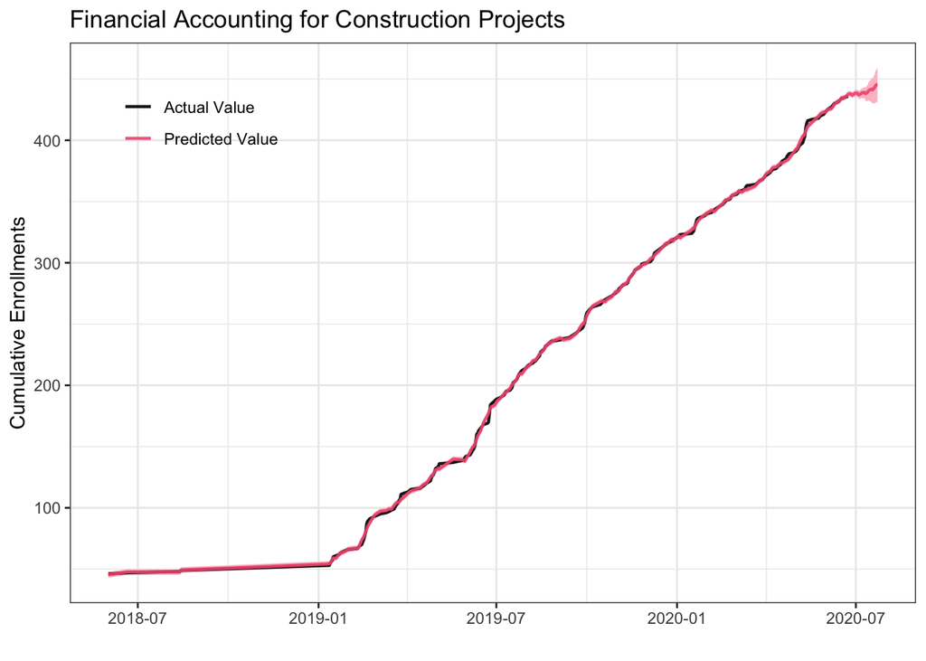

```r
# Function to plot a course:-----------------------------------------------------
runplot4one = function(crse_name, dt_tune) {
  cp = dt_tune[course == crse_name]$cp
  seas = dt_tune[course == crse_name]$seas
  algorithm = dt_crsa_par[CRSE_NM == crse_name]$algorithm
  mod = prophet(dt_coursera[CRSE_NM == crse_name, .(ds, y)],
                algorithm = algorithm,
                changepoint.prior.scale = cp,
                seasonality.prior.scale = seas)
  future = make_future_dataframe(mod, periods = 30, freq = "day")
  forecast = predict(mod, future)
  predicted_df = forecast[c('ds', 'yhat', 'yhat_lower', 'yhat_upper')]
  y = dt_coursera[CRSE_NM == crse_name]$y
  length(y) = nrow(predicted_df)
  df = cbind(predicted_df, y) %>%
    pivot_longer(cols = c("yhat", "y"))

  cols = c("y" = "black", "yhat" = "#f15c80")
  gg = ggplot(df, aes(ds)) +
    geom_ribbon(aes(ymin = yhat_lower, ymax = yhat_upper), fill="pink") +
    geom_line(aes(y = value, group = name, color = name), size = .8, alpha=.9) +
    scale_colour_manual(values = cols,
                        labels = c("Actual Value", "Predicted Value")) +
    xlab("") + ylab("Cumulative Enrollments") + theme_bw() +
    ggtitle(crse_name) +
    theme(legend.title = element_blank(),
          legend.justification=c(0,1),
          legend.position=c(0.05, 0.95),
          legend.background = element_blank(),
          legend.key = element_blank())
  return(gg)
}

# Function to tune hyper-parameters for a course: -------------------------------
tune_par = function(crse_name, len, cp_prior_vals_min, cp_prior_vals_max,
                    seas_prior_vals_min, seas_prior_vals_max) {
  set.seed(2020)
  cp_prior_vals = runif(len, cp_prior_vals_min, cp_prior_vals_max)
  seas_prior_vals = runif(len, seas_prior_vals_min, seas_prior_vals_max)
  rmse = vector(length = len)
  mape = vector(length = len)
  for (i in 1:len) {
    tryCatch({
      algorithm = dt_crsa_par[CRSE_NM == crse_name]$algorithm
      mod = prophet(dt_coursera[CRSE_NM == crse_name, .(ds, y)],
                    algorithm = algorithm,
                    changepoint.prior.scale = cp_prior_vals[i],
                    seasonality.prior.scale = seas_prior_vals[i])
      future = make_future_dataframe(mod, periods = 30, freq = "day")
      forecast = predict(mod, future)
      horizon = dt_crsa_par[CRSE_NM == crse_name]$horizon
      cv = cross_validation(mod, horizon = horizon, units = "days")
      rmse[i] = performance_metrics(cv, metrics = 'rmse', rolling_window = 1)$rmse
      mape[i] = performance_metrics(cv, metrics = 'mape', rolling_window = 1)$mape*100
    }, error = function(e){
      cat("ERROR:", j, i, conditionMessage(e), "\n")})
  }

  df = data.frame(cbind(rep(course, len), cp_prior_vals, seas_prior_vals,
                        round(rmse, 2), round(mape, 2)))
  colnames(df) = c("course", "cp_prior_vals", "seas_prior_vals","rmse", "mape")
  return(df)
}
# Plot the course
crse_name = "Financial Accounting for Construction Projects"
runplot4one(crse_name, dt_tune)
```

After further tuning, MAPE improved by 10.99%.

|  | changepoint.prior.scale | seasonality.prior.scale | MAPE |
| --- | --- | --- | --- |
| Baseline Model | 0.05 | 10 | 16.86 |
| Add seasonality.mode = “multiplicative” |  |  | 21.76 |
| 2nd Model | 4.08 | 18.19 | 24.54 |
| 3rd Model | 4.51 | 0.026 | 5.87 |

## Using Python to Access Web Data

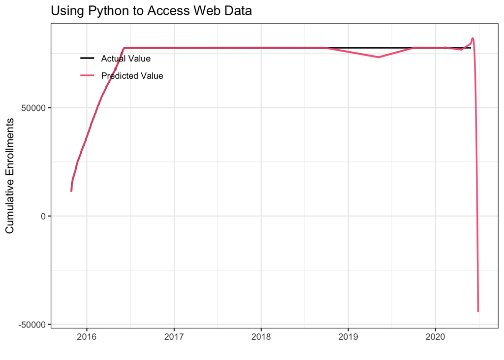

```r
crse_name = "Using Python to Access Web Data"
runplot4one(crse_name, dt_tune)
```

On 2015-10-30, we got 2705 enrollments which is a bit weird. I’ve gone back to check the raw data, it shouldn’t be my coding error.

20 sets of parameters were generated through $Unif(0, 10)$ for *changepoint.prior.scale* and $Unif(0, 20)$ for *seasonality.prior.scale*.

```r
datatable(dt_coursera[CRSE_NM == "Using Python to Access Web Data",
          .(ds, CNT, y)],
          caption = "Table 3: Enrollments for Using Python to Access Web Data")
```

|  | ds | CNT | y |
| --- | --- | --- | --- |
| 1 | 2015-10-27 | 363 | 11419 |
| 2 | 2015-10-28 | 247 | 11666 |
| 3 | 2015-10-29 | 285 | 11951 |
| 4 | 2015-10-30 | 2705 | 14656 |
| 5 | 2015-10-31 | 552 | 15208 |
| 6 | 2015-11-01 | 522 | 15730 |
| 7 | 2015-11-02 | 676 | 16406 |
| 8 | 2015-11-03 | 551 | 16957 |
| 9 | 2015-11-04 | 406 | 17363 |
| 10 | 2015-11-05 | 440 | 17803 |

[output cut: 223 more lines]

After further tuning, MAPE improved by 35.24%.

|  | changepoint.prior.scale | seasonality.prior.scale | MAPE |
| --- | --- | --- | --- |
| Baseline Model | 0.05 | 10 | 55.79 |
| Add seasonality.mode = “multiplicative” |  |  | 82.75 |
| 2nd Model | 18.56 | 26.52 | 37.34 |
| 3rd Model | 8.87 | 0.13 | 20.55 |

## Introduction to Natural Language Processing

Like what we observed earlier, the model didn’t do well the the step-like curve. It predicts a upward trend for the next 30 days, while the trend of enrollments remains flat.

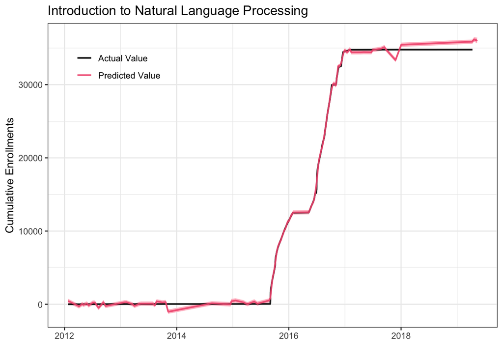

```r
crse_name = "Introduction to Natural Language Processing"
runplot4one(crse_name, dt_tune)
```

|  | changepoint.prior.scale | seasonality.prior.scale | MAPE |
| --- | --- | --- | --- |
| Baseline Model | 0.05 | 10 | 35.61 |
| Add seasonality.mode = “multiplicative” |  |  | 82.75 |
| 2nd Model | 11.79 | 23.07 | 19.28 |
| 3rd Model | 8.19 | 0.01 | 18.27 |

## Understanding and Improving the US Healthcare System

(Haven’t started)

# Issue

- Inconsistent course name for “Programming for Everybody (Python)” and “Accounting for Decision Making”.

```r
crse = fread("./raw_data/oldw_crse_7-2-20.csv", encoding='UTF-8')
crse[grepl("Programming for Everybody|Accounting for Decision Making", CRSE_NM),
     .(CRSE_NM, SRC_SYS_CD)] %>%
  .[SRC_SYS_CD %in% c("CRSAPHX", "CRSASPRK")] %>% .[order(CRSE_NM)]
```

```
##                                                    CRSE_NM SRC_SYS_CD
## 1:                          Accounting for Decision Making    CRSAPHX
## 2:      Accounting for Decision Making: Fast Track Finance    CRSAPHX
## 3: Programming for Everybody (Getting Started with Python)    CRSAPHX
## 4:                      Programming for Everybody (Python)   CRSASPRK
```

# Next Step…

- Courses not yet fitted

```r
# Course not yet explore
crse_unexplore = unique(dt_coursera$CRSE_NM)[!unique(dt_coursera$CRSE_NM)
                                             %in% tbl$course]
crse_unexplore
```

```
##  [1] "Applied Social Network Analysis in Python"
##  [2] "Beyond the Sustainable Development Goals (SDGs): Addressing Sustainability and Development"
##  [3] "Construction Safety and Human Factors"
##  [4] "Fast Track Finance #1"
##  [5] "Fast Track Finance #6"
##  [6] "Finding Purpose and Meaning In Life: Living for What Matters Most"
##  [7] "Hearing Loss in Children"
##  [8] "Instructional Methods in Health Professions Education (Guyana)"
##  [9] "Introduction to Data Science in Python"
## [10] "Leading People and Teams Capstone"
## [11] "MADS Python Entrance Assessment A"
## [12] "MADS Python Entrance Assessment B"
## [13] "MADS Python and Statistics Entrance Assessment"
## [14] "MADS Statistics Entrance Assessment"
## [15] "MADS Statistics Entrance Assessment A"
## [16] "Master of Applied Data Science Student Orientation"
## [17] "Model Thinking ?????????"
## [18] "Practical Learning Analytics"
## [19] "Questionnaire Design for Social Surveys"
## [20] "Using Databases with Python"
## [21] "Valuation Capstone"
## [22] "Valuing Projects and Companies"
## [23] "Writing and Editing: Drafting"
## [24] "Writing and Editing: Revising"
## [25] "Writing and Editing: Structure and Organization"
## [26] "Writing and Editing: Word Choice and Word Order"
```

# References

- Implementing Facebook Prophet efficiently. https://towardsdatascience.com/implementing-facebook-prophet-efficiently-c241305405a3
- Inconsistent diagnosis and how to improve MAPE. https://github.com/facebook/prophet/issues/1058

**Links for better understand prophet**

- Why do we need to fit the model before doing cross validation? https://github.com/facebook/prophet/issues/1409
- Hyperparameter Tuning Snippet. https://github.com/facebook/prophet/issues/1381
- Effect of changepoint_prior_scale and seasonality_prior_scale. https://github.com/facebook/prophet/issues/1320